# Deep Learning- 課程 06－Deep Learning- R-CNN - Python Tutorial

[figure not shown]

''' >> 物件偵測 結構 - Object Detection Structure - One Stage Object Detection - Two Stage Object Detection '''

[figure not shown]

''' >> R-CNN系列 - 模型摘要 >> R-CNN Family '''

[figure not shown]

''' >> 物件偵測 結構 - One Stage Object Detection - YoLov1 - YoLov2 - YoLov3 - Tiny YOLO - SSD '''

[figure not shown]

''' >> 物件偵測 結構 - Two Stage Object Detection - R-CNN - Fast R-CNN - Faster R-CNN '''

[figure not shown]

''' >> R-CNN 系統 - System R-CNN 系統 - R-CNN (Region Convolution Neural Network) - R-CNN（Selective Search + CNN + SVM） '''

[figure not shown]

''' >> R-CNN 系統 System - 試圖解決的問題 - 圖像中定位對象（對象檢測） - 如何解決這個問題 - 可以從滑動窗口方法開始 - 方法 - 只需遍歷具有不同大小的矩形的整個圖像 - 然後查看那些較小的圖像 - 問題是 - 將要查看大量 - 較小的圖像 - 開發了演算法 - Algorithms - 聰明地 選擇那些所謂的區域提議 - Region Proposals - 簡化這個概念： - 區域提議 - - 只是原始圖像的較小部分 - 其中 - 包含要 - 搜索的對象 '''''' >> Selective Search - 選擇性 搜尋 '''

[figure not shown]

''' >> 目標檢測 - 圖像中 - 存在多個物體 - 需要 分別 定位 和 分類 - 比圖像分類較複雜 - 很重要的一個因素是 - 在訓練分類器之前 >> 需要使用一些方法 - 將圖像劃分為小的區域 - 這些方法 - Region Proposal - 演算法 - Algorithms - 聰明地 - 選擇那些 - 所謂的區域提議 - Region Proposals - 簡化這個概念： - 區域提議 - - 只是原始圖像的較小部分 - 其中 - 包含要 - 搜索的對象 - 一張圖像中 - 包含的信息非常豐富 - 圖像中的物體 - 有不同的形狀 Shape 、尺寸 Size 、顏色 Coloer 、紋理 Texture - 而且物體間還有層次 - Hierarchical - 關係 - 目標檢測的圖像物體的多樣性 - Diversity '''

[figure not shown]

''' >> 區域提議 - Region Proposals - 窮舉法 - Exhaustive Search - 分割法 - Segmentation - 選擇性搜尋 - Selective Search '''''' - 窮舉法 - Exhaustive Search - 遍歷圖像的每一個像素 Pixels - 導致搜索的範圍很大，需要的計算量也很大 - 最後產生的 - 提議區域 - 也很多 - 窮舉法 產生 ~ 100000 多個 ~ 提議區域 - 不合適使用 - 在複雜的 - 特徵提取 演算法 / 分類器 - HOG +SVM '''''' - 分割法 - Segmentation - 通過生成多個 - 前景/背景 - 通過一定標準預測前景分割區域 - 是一個完整對象區域的可能性大小（預測一個可能性大小） - 根據 - 這個可能性大小對分割進行排序， - 可以精確地描繪出圖像中的物體 - 分割方法太單一 - 沒有多樣性 '''''' - 選擇性搜尋 SS - Selective Search - 三個優勢 - 捕捉不同尺度 - Capture All Scales - 多樣化 - Diversification - 計算快速 - Fast to Compute - 選擇性搜索 - 用於目標檢測的 - 區域提議算法 - 計算速度快 - 具有很高的召回率 - 基於顏色，紋理，大小和形狀兼容計算相似區域的分層分組 - Selective Search 演算法 - 包含兩個主要 演算法 - Hierarchical Grouping Algorithm - Diversification Strategies '''''' - Hierarchical Grouping Algorithm - 計算 - 鄰近區域之間的相似性； - 兩個最相似的區域 - 被組合在一起 - 計算 - 合併區域和相鄰區域的相似度 - 重複2、3過程 - 直到整個圖像 - 變為一個地區 - 每次迭代中 - 形成更大的區域 - 將添加 - 到區域提議列表中 - 以自下而上的方式創建 - 從較小的細分 Segments - 到較大細分 Segments - 區域提案 '''

[figure not shown]

''' - Diversification Strategies - 利用各種不同不變性的色彩空間 - 採用不同的相似性度量 - 通過改變起始區域 - 顏色相似度衡量 - Colour Spaces Similarity Measures - 紋理相似度衡量 - Texture Similarity Measures - 尺度相似度衡量 - Size Similarity Measures - 形狀相似度衡量 - Shape Similarity Measures >> 最終的 - 相似度衡量 '''

[figure not shown]

''' >> 下一步 - Next Step - CNN - 卷積神經網絡 Convolutional Neural Network - 採用每個區域建議 - 使用卷積神經網絡（CNN） - 創建一個以較小尺寸 - 該圖像的特徵向量 - AlexNet 特徵提取 - Feature Extractor - AlexNet 輸入 - 227、227、3 '''

[figure not shown]

''' >> 支持向量機 - SVM Classificator - 圖像 - 特徵向量 - 對那些特徵向量 - 進行分類 - 檢測 特徵向量 - 代表的 對像類別 '''

[figure not shown]

''' >> R-CNN - R - 一張圖片-創建了不同的圖片建議 - CNN - 建議中 - 創建了特徵向量 - SVM - 每個對像類 - 每個特徵向量 - 進行分類 >> Bounding Box Regressor >> 區域 Region Proposal - 圖像提議 Images Proposal - IoU intersection-over-union (IoU) - 與得分較高的選定區域 重疊 - 拒絕該區域 - 非最大抑制 Non-Maximum Suppression NMS - 刪除 - 同一對象的 - 重複預測 '''

[figure not shown]

```python
# pip Installation  mxnet and gluoncv - model_zoo

# Model Zoo  - Classification on Object Detection

pip install --upgrade mxnet gluoncv
```

```python
!pip install --upgrade mxnet gluoncv
```

# 程式範例

```python
!python -V
```

```
Python 3.7.3
```

```python
import tensorflow as tf
tf.__version__
```

```
'1.14.0'
```

```python
import cv2
cv2.__version__
```

```
'4.1.0'
```

''' >> 查看原始照片 - Review Orginal Phote '''

```python
%matplotlib inline
import cv2
import numpy as np
import matplotlib.pyplot as plt
```

[output not shown]

```python
img = cv2.imread('images/dog.jpg')
img = cv2.cvtColor(img, cv2.COLOR_BGR2RGB)
plt.figure(figsize = (20, 20))
plt.subplot(1, 2, 1); plt.imshow(img)
img.shape
```

```
(424, 640, 3)
```

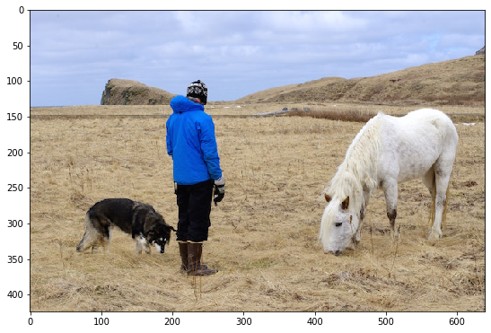

```python
img = cv2.imread('images/person.jpg')
img1 = cv2.cvtColor(img, cv2.COLOR_BGR2RGB)
plt.figure(figsize = (20, 20))
plt.subplot(1, 2, 1); plt.imshow(img1)
img1.shape
```

```
(600, 956, 3)
```

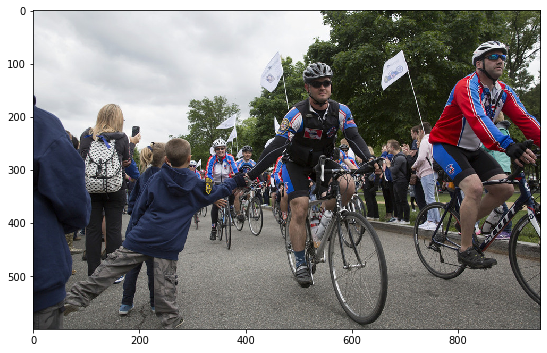

```python
img = cv2.imread('images/biking.jpg')
img1 = cv2.cvtColor(img, cv2.COLOR_BGR2RGB)
plt.figure(figsize = (20, 20))
plt.subplot(1, 2, 1); plt.imshow(img1)
img1.shape
```

[output not shown]

## 載入相關函式庫 - Load related library

''' >> Simple Pose models >> 預訓練模型 model_zoo.get_model(' ') - detector = model_zoo.get_model('yolo3_mobilenet1.0_coco', pretrained=True) - pose_net = model_zoo.get_model('simple_pose_resnet18_v1b', pretrained=True) '''

```python
from matplotlib import pyplot as plt
from gluoncv import model_zoo, data, utils
from gluoncv.data.transforms.pose import detector_to_simple_pose, heatmap_to_coord
```

## 加載預訓練的模型 - Load yolo3_mobilenet1.0_coco / simple_pose_resnet18_v1b

''' >> 一個簡單姿勢模型 - 模型 - MS COCO數據集上大小 - 256x192的輸入圖像進行訓練 - 選擇一個使用ResNet-18 V1b - 基本模型的模型 - pretrained = True ，- 要時它將自動從模型model_zoo 中下載模型 - 簡單姿勢模型 - 採用自上而下 - 對象檢測模型中 - 估計檢測到 - 邊界框中的人體姿勢 '''

```python
detector = model_zoo.get_model('yolo3_mobilenet1.0_coco', pretrained=True)
pose_net = model_zoo.get_model('simple_pose_resnet18_v1b', pretrained=True)

# Select the classes  類別 - person, NMS process is faster.

detector.reset_class(["person"], reuse_weights=['person'])
```

## 預處理圖像 Pre-process an image

''' - 預處理圖像 -------------------- - 下載圖像 - 使用預設的數據轉換 - 進行預處理 - 默認 - 圖像的短邊尺寸調整為 600px - 可以提供任意大小的圖像 - >> gluoncv.data.transforms.presets.rcnn.load_test - 形狀為（batch_size，RGB_channels，height，width）的 NDArray - 可以直接將其 輸入模型 - 加載單個圖像 - x 第一維為 1 - orig_img - 大小 - 已調整為 x 512 '''

```python
ddir
```

```python
im_fname = utils.download('https://github.com/dmlc/web-data/blob/master/' +
                          'gluoncv/pose/soccer.png?raw=true',
                          path='soccer.png')
x, img = data.transforms.presets.ssd.load_test(im_fname, short=512)
print('Shape of pre-processed image:', x.shape)

class_IDs, scores, bounding_boxs = detector(x)
```

```
Shape of pre-processed image: (1, 3, 512, 605)
```

```python
x.shape,x.dtype
```

```
((1, 3, 512, 605), numpy.float32)
```

```python
im_fname = utils.download('person.jpg')

x, img = data.transforms.presets.ssd.load_test(im_fname, short=512)
print('Shape of pre-processed image:', x.shape)

class_IDs, scores, bounding_boxs = detector(x)
```

```
Shape of pre-processed image: (1, 3, 512, 773)
```

```python
x.shape,x.dtype
```

```
((1, 3, 512, 773), numpy.float32)
```

```python
im_fname = utils.download('dog.jpg')

x, img = data.transforms.presets.ssd.load_test(im_fname, short=512)
print('Shape of pre-processed image:', x.shape)

class_IDs, scores, bounding_boxs = detector(x)
```

```
Shape of pre-processed image: (1, 3, 512, 683)
```

```python
x.shape,x.dtype
```

```
((1, 3, 512, 683), numpy.float32)
```

```python
im_fname = utils.download('biking.jpg')

x, img = data.transforms.presets.ssd.load_test(im_fname, short=512)
print('Shape of pre-processed image:', x.shape)

class_IDs, scores, bounding_boxs = detector(x)
```

```
Shape of pre-processed image: (1, 3, 512, 816)
```

```python
x.shape,x.dtype
```

```
((1, 3, 512, 816), numpy.float32)
```

''' >> 檢測器 Detector - 關鍵點網絡 keypoint network - 張量 Tensor - 簡單姿勢網絡 - 輸入的大小 - 256x192 - 裁剪邊框區域 - 每個人 - 大小調整 - 為256x192，最後將其標準化。 - 為了確保邊界框 - 包括整個人 - 通常會稍微放大 - Box Size - 尺寸 '''

```python
pose_input, upscale_bbox = detector_to_simple_pose(img, class_IDs, scores, bounding_boxs)
```

''' >> 姿勢 Pose predict 估計 - 使用 - 簡單姿勢網絡 Simple Pose Network - Simple Pose Network - 可預測每個關節的熱圖 - 關鍵點 Keypoint - 推論之後 - 熱圖 Heatmap中搜索最高值 - 並將其映射 mapping 到 - 原始圖像上的坐標 '''

```python
predicted_heatmap = pose_net(pose_input)
pred_coords, confidence = heatmap_to_coord(predicted_heatmap, upscale_bbox)
```

## 檢/ 偵測 和 顯示 - Detection and Display

''' - 顯示姿勢 Pose Estimation - 估計結果 - 使用：py：func： - gluoncv.utils.viz.plot_keypoints 可視化 結果 '''

[figure not shown]

```
Wall time: 305 ms
```

```python
%%time
ax = utils.viz.plot_keypoints(img, pred_coords, confidence,
                              class_IDs, bounding_boxs, scores,
                              box_thresh=0.5, keypoint_thresh=0.2)
plt.show()
```

[figure not shown]

```
Wall time: 433 ms
```

```python
%%time
ax = utils.viz.plot_keypoints(img, pred_coords, confidence,
                              class_IDs, bounding_boxs, scores,
                              box_thresh=0.5, keypoint_thresh=0.2)
plt.show()
```

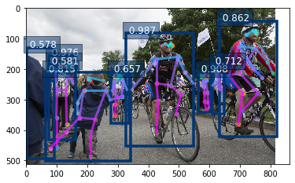

```
Wall time: 810 ms
```

```python
%%time
ax = utils.viz.plot_keypoints(img, pred_coords, confidence,
                              class_IDs, bounding_boxs, scores,
                              box_thresh=0.5, keypoint_thresh=0.2)
plt.show()
```